```python
from scipy.stats import chi2
import numpy as np
import seaborn as sns
import matplotlib.pyplot as plt
```

# Exercice TD stats khi2 sur le dé

Il y a deux catégories (1,2,3,4 d'un côté et 5,6 de l'autre) or nombre de degrés de liberté=nombre de catégories-1 car malgré les fluctuations d'échantillonage, la somme des observations sur les deux catégories est contrainte à être égale au nombre de tirages.

Si les dés sont parfaits, alors $\sum_{categories}\frac{(observe-theorique)^2}{theorique}$ suit une distribution du $\chi2$ à un degré de liberté.

Regardons si l'écart (dite "statistique de $\chi^2$") $\sum_{categories}\frac{(observe-theorique)^2}{theorique}$ constaté dans notre problème a une chance raisonnable d'être généré par cette distribution. S'il est trop grand, on considèrera que les fluctuations d'échantillonnage ne suffisent pas à expliquer la déviation mesurée entre effectifs théoriques et effectifs observés.

Choisissons (arbitrairement) un seuil de 5%, c'est à dire qu'on va chercher la valeur du $\chi2$ qui n'a que 5% de chances d'être dépassée dans la cas où les dés sont parfaits. La table du $\chi2$ donne un seuil=3.841. Le principe est que qu'il est très peu probable la statistique de $\chi2$ dépasse ce seuil avec des dés réguliers et donc, si elle le dépasse, on concluera que le dé est irrégulier.

Ce seuil peut être obtenu en python comme suit (où q= 5% et df = degrees of freedom =1) :

```python
print (chi2.isf(q=0.05,df=1))
```

```
3.8414588206941285
```

Calculons la statistique du $\chi2$ pour notre problème :

|  | 1 à 4 | 5 et 6 |
| --- | --- | --- |
| Effectif observé | 315672-106602 | 106602 |
| Effectif théorique | 2/3*315672 | 315672/3 |

```python
observe_categorie1=106602
theorique_categorie1=315672/3

observe_categorie2=315672-106602
theorique_categorie2= 2/3*315672

khi2 = (observe_categorie1-theorique_categorie1)**2/theorique_categorie1+(observe_categorie2-theorique_categorie2)**2/theorique_categorie2
print(khi2)
```

```
27.069166730023568
```

Cette statistique d'écart est bien supérieure au seuil trouvé précédemment. On peut conclure que le dé n'est pas parfait.

**Supplément 1** : traçons la densité de probabilité de $\chi2$ pour 1 degré de liberté, qui nous confirmera que la densité de probabilité est très très faible quand on arrive à 27.06 en abscisse

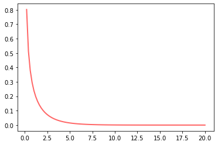

```python
df=1  #Degrés de liberté

x = np.linspace(0,20, 100) # Pour dessiner l'axe des abscisses
plt.plot(x, chi2.pdf(x, df), 'r-', lw=2, alpha=0.6, label='chi2 pdf')
```

**Supplément 2** On pourrait aussi traiter ce problème comme un tirage d'une loi binomiale de paramètre n=315672 et p=1/3. Procédons à 5000 tirages aléatoires (comme si on tirait 5000 fois 315672 un dé). Regardons l'histogramme des résultats obtenus pour voir comment se positionne 106602. On voit que 106602 est loin de la zone la zone de concentration de la distribution, confirmant la conclusion qu'on avait tirée par le test du $\chi^2$ que les dés ne sont pas parfaits.

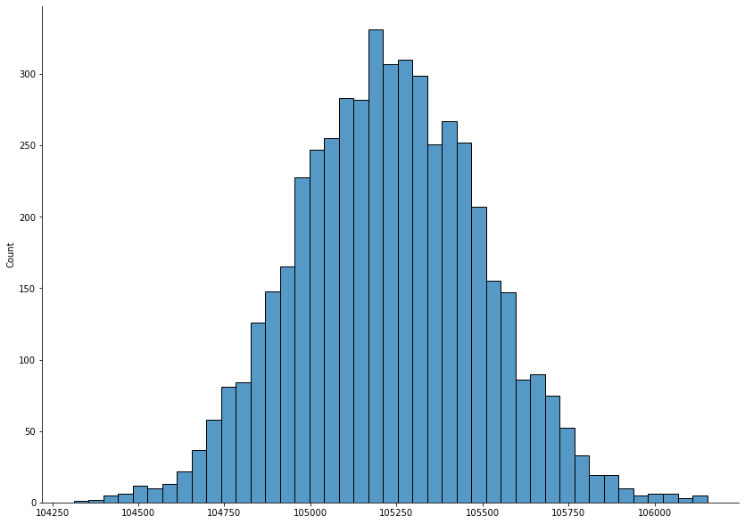

```python
s = np.random.binomial(n=theorique*3, p=1/3,size=5000)


sns.displot(data=s,height=8.27, aspect=11.7/8.27)
```